# Risk Factor Analysis

## Outcome Variable

**Outcome Variable:** y_rate_len

## Predictor Variables

**Intervention Variable:** trth2o

**Adjustment Set:**

- arm
- sex
- W_mage
- meducyrs
- feducyrs
- hfoodsec
- W_mhtcm
- W_mwtkg
- W_mbmi
- W_nrooms
- W_nhh
- W_nchldlt5
- cleanck
- impfloor
- impsan
- safeh20
- delta_meducyrs
- delta_feducyrs
- delta_hfoodsec
- delta_W_mhtcm
- delta_W_mwtkg
- delta_W_mbmi
- delta_W_nrooms
- delta_W_nhh
- delta_W_nchldlt5
- delta_cleanck
- delta_impfloor
- delta_impsan
- delta_safeh20

## Stratifying Variables

The analysis was stratified on these variable(s):

- agecat
- studyid
- country

## Data Summary

| agecat | studyid | country | trth2o | n_cell | n |
| --- | --- | --- | --- | --- | --- |
| 0-3 months | ki0047075b-MAL-ED | BANGLADESH | 0 | 2 | 134 |
| 0-3 months | ki0047075b-MAL-ED | BANGLADESH | 1 | 132 | 134 |
| 0-3 months | ki0047075b-MAL-ED | BRAZIL | 0 | 72 | 84 |
| 0-3 months | ki0047075b-MAL-ED | BRAZIL | 1 | 12 | 84 |
| 0-3 months | ki0047075b-MAL-ED | INDIA | 0 | 4 | 6 |
| 0-3 months | ki0047075b-MAL-ED | INDIA | 1 | 2 | 6 |
| 0-3 months | ki0047075b-MAL-ED | NEPAL | 0 | 12 | 63 |
| 0-3 months | ki0047075b-MAL-ED | NEPAL | 1 | 51 | 63 |
| 0-3 months | ki0047075b-MAL-ED | PERU | 0 | 9 | 46 |
| 0-3 months | ki0047075b-MAL-ED | PERU | 1 | 37 | 46 |
| 0-3 months | ki0047075b-MAL-ED | SOUTH AFRICA | 0 | 9 | 10 |
| 0-3 months | ki0047075b-MAL-ED | SOUTH AFRICA | 1 | 1 | 10 |
| 0-3 months | ki0047075b-MAL-ED | TANZANIA, UNITED REPUBLIC OF | 0 | 32 | 38 |
| 0-3 months | ki0047075b-MAL-ED | TANZANIA, UNITED REPUBLIC OF | 1 | 6 | 38 |
| 0-3 months | ki1000108-CMC-V-BCS-2002 | INDIA | 0 | 0 | 25 |
| 0-3 months | ki1000108-CMC-V-BCS-2002 | INDIA | 1 | 25 | 25 |
| 0-3 months | ki1000108-IRC | INDIA | 0 | 0 | 118 |
| 0-3 months | ki1000108-IRC | INDIA | 1 | 118 | 118 |
| 0-3 months | ki1017093b-PROVIDE | BANGLADESH | 0 | 620 | 634 |
| 0-3 months | ki1017093b-PROVIDE | BANGLADESH | 1 | 14 | 634 |
| 0-3 months | ki1017093c-NIH-Crypto | BANGLADESH | 0 | 319 | 720 |
| 0-3 months | ki1017093c-NIH-Crypto | BANGLADESH | 1 | 401 | 720 |
| 3-6 months | ki0047075b-MAL-ED | BANGLADESH | 0 | 2 | 132 |
| 3-6 months | ki0047075b-MAL-ED | BANGLADESH | 1 | 130 | 132 |
| 3-6 months | ki0047075b-MAL-ED | BRAZIL | 0 | 90 | 103 |
| 3-6 months | ki0047075b-MAL-ED | BRAZIL | 1 | 13 | 103 |
| 3-6 months | ki0047075b-MAL-ED | INDIA | 0 | 4 | 7 |
| 3-6 months | ki0047075b-MAL-ED | INDIA | 1 | 3 | 7 |
| 3-6 months | ki0047075b-MAL-ED | NEPAL | 0 | 14 | 82 |
| 3-6 months | ki0047075b-MAL-ED | NEPAL | 1 | 68 | 82 |

[output cut: 64 more lines]

The following strata were considered:

- agecat: 0-3 months, studyid: ki0047075b-MAL-ED, country: BANGLADESH
- agecat: 0-3 months, studyid: ki0047075b-MAL-ED, country: BRAZIL
- agecat: 0-3 months, studyid: ki0047075b-MAL-ED, country: INDIA
- agecat: 0-3 months, studyid: ki0047075b-MAL-ED, country: NEPAL
- agecat: 0-3 months, studyid: ki0047075b-MAL-ED, country: PERU
- agecat: 0-3 months, studyid: ki0047075b-MAL-ED, country: SOUTH AFRICA
- agecat: 0-3 months, studyid: ki0047075b-MAL-ED, country: TANZANIA, UNITED REPUBLIC OF
- agecat: 0-3 months, studyid: ki1000108-CMC-V-BCS-2002, country: INDIA
- agecat: 0-3 months, studyid: ki1000108-IRC, country: INDIA
- agecat: 0-3 months, studyid: ki1017093b-PROVIDE, country: BANGLADESH
- agecat: 0-3 months, studyid: ki1017093c-NIH-Crypto, country: BANGLADESH
- agecat: 12-24 months, studyid: ki0047075b-MAL-ED, country: BANGLADESH
- agecat: 12-24 months, studyid: ki0047075b-MAL-ED, country: BRAZIL
- agecat: 12-24 months, studyid: ki0047075b-MAL-ED, country: INDIA
- agecat: 12-24 months, studyid: ki0047075b-MAL-ED, country: NEPAL
- agecat: 12-24 months, studyid: ki0047075b-MAL-ED, country: PERU
- agecat: 12-24 months, studyid: ki0047075b-MAL-ED, country: SOUTH AFRICA
- agecat: 12-24 months, studyid: ki0047075b-MAL-ED, country: TANZANIA, UNITED REPUBLIC OF
- agecat: 12-24 months, studyid: ki1000108-CMC-V-BCS-2002, country: INDIA
- agecat: 12-24 months, studyid: ki1000108-IRC, country: INDIA
- agecat: 12-24 months, studyid: ki1017093b-PROVIDE, country: BANGLADESH
- agecat: 12-24 months, studyid: ki1017093c-NIH-Crypto, country: BANGLADESH
- agecat: 12-24 months, studyid: ki1113344-GMS-Nepal, country: NEPAL
- agecat: 3-6 months, studyid: ki0047075b-MAL-ED, country: BANGLADESH
- agecat: 3-6 months, studyid: ki0047075b-MAL-ED, country: BRAZIL
- agecat: 3-6 months, studyid: ki0047075b-MAL-ED, country: INDIA
- agecat: 3-6 months, studyid: ki0047075b-MAL-ED, country: NEPAL
- agecat: 3-6 months, studyid: ki0047075b-MAL-ED, country: PERU
- agecat: 3-6 months, studyid: ki0047075b-MAL-ED, country: SOUTH AFRICA
- agecat: 3-6 months, studyid: ki0047075b-MAL-ED, country: TANZANIA, UNITED REPUBLIC OF
- agecat: 3-6 months, studyid: ki1000108-CMC-V-BCS-2002, country: INDIA
- agecat: 3-6 months, studyid: ki1000108-IRC, country: INDIA
- agecat: 3-6 months, studyid: ki1017093b-PROVIDE, country: BANGLADESH
- agecat: 3-6 months, studyid: ki1017093c-NIH-Crypto, country: BANGLADESH
- agecat: 3-6 months, studyid: ki1113344-GMS-Nepal, country: NEPAL
- agecat: 6-12 months, studyid: ki0047075b-MAL-ED, country: BANGLADESH
- agecat: 6-12 months, studyid: ki0047075b-MAL-ED, country: BRAZIL
- agecat: 6-12 months, studyid: ki0047075b-MAL-ED, country: INDIA
- agecat: 6-12 months, studyid: ki0047075b-MAL-ED, country: NEPAL
- agecat: 6-12 months, studyid: ki0047075b-MAL-ED, country: PERU
- agecat: 6-12 months, studyid: ki0047075b-MAL-ED, country: SOUTH AFRICA
- agecat: 6-12 months, studyid: ki0047075b-MAL-ED, country: TANZANIA, UNITED REPUBLIC OF
- agecat: 6-12 months, studyid: ki1000108-CMC-V-BCS-2002, country: INDIA
- agecat: 6-12 months, studyid: ki1000108-IRC, country: INDIA
- agecat: 6-12 months, studyid: ki1017093b-PROVIDE, country: BANGLADESH
- agecat: 6-12 months, studyid: ki1017093c-NIH-Crypto, country: BANGLADESH
- agecat: 6-12 months, studyid: ki1113344-GMS-Nepal, country: NEPAL

### Dropped Strata

Some strata were dropped due to rare outcomes:

- agecat: 0-3 months, studyid: ki0047075b-MAL-ED, country: BANGLADESH
- agecat: 0-3 months, studyid: ki0047075b-MAL-ED, country: INDIA
- agecat: 0-3 months, studyid: ki0047075b-MAL-ED, country: SOUTH AFRICA
- agecat: 0-3 months, studyid: ki1000108-CMC-V-BCS-2002, country: INDIA
- agecat: 0-3 months, studyid: ki1000108-IRC, country: INDIA
- agecat: 3-6 months, studyid: ki0047075b-MAL-ED, country: BANGLADESH
- agecat: 3-6 months, studyid: ki0047075b-MAL-ED, country: INDIA
- agecat: 3-6 months, studyid: ki0047075b-MAL-ED, country: SOUTH AFRICA
- agecat: 3-6 months, studyid: ki1000108-CMC-V-BCS-2002, country: INDIA
- agecat: 3-6 months, studyid: ki1000108-IRC, country: INDIA
- agecat: 3-6 months, studyid: ki1113344-GMS-Nepal, country: NEPAL
- agecat: 6-12 months, studyid: ki0047075b-MAL-ED, country: BANGLADESH
- agecat: 6-12 months, studyid: ki0047075b-MAL-ED, country: INDIA
- agecat: 6-12 months, studyid: ki0047075b-MAL-ED, country: SOUTH AFRICA
- agecat: 6-12 months, studyid: ki1000108-CMC-V-BCS-2002, country: INDIA
- agecat: 6-12 months, studyid: ki1000108-IRC, country: INDIA
- agecat: 6-12 months, studyid: ki1113344-GMS-Nepal, country: NEPAL
- agecat: 12-24 months, studyid: ki0047075b-MAL-ED, country: BANGLADESH
- agecat: 12-24 months, studyid: ki0047075b-MAL-ED, country: INDIA
- agecat: 12-24 months, studyid: ki0047075b-MAL-ED, country: SOUTH AFRICA
- agecat: 12-24 months, studyid: ki1000108-CMC-V-BCS-2002, country: INDIA
- agecat: 12-24 months, studyid: ki1000108-IRC, country: INDIA
- agecat: 12-24 months, studyid: ki1113344-GMS-Nepal, country: NEPAL

## Methods Detail

We’re interested in the causal parameters $E[Y_a]$ for all values of $a \in \mathcal{A}$. These parameters represent the mean outcome if, possibly contrary to fact, we intervened to set all units to have $A=a$. Under the randomization and positivity assumptions, these are identified by the statistical parameters $\psi_a=E_W[E_{Y|A,W}(Y|A=a,W)]$. In addition, we’re interested in the mean of $Y$, $E[Y]$ under no intervention (the observed mean). We will estimate these parameters by using SuperLearner to fit the relevant likelihood factors – $E_{Y|A,W}(Y|A=a,W)$ and $p(A=a|W)$, and then updating our likelihood fit using a joint TMLE.

For unadjusted analyses ($W=\{\}$), initial likelihoods were estimated using Lrnr_glm to estimate the simple $E(Y|A)$ and Lrnr_mean to estimate $p(A)$. For adjusted analyses, a small library containing Lrnr_glmnet, Lrnr_xgboost, and Lrnr_mean was used.

# Results Detail

## Results Plots

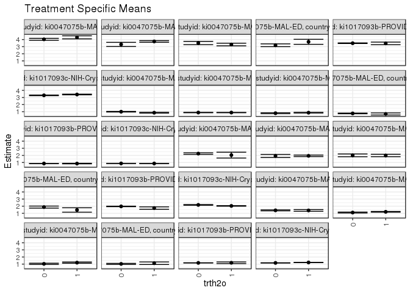

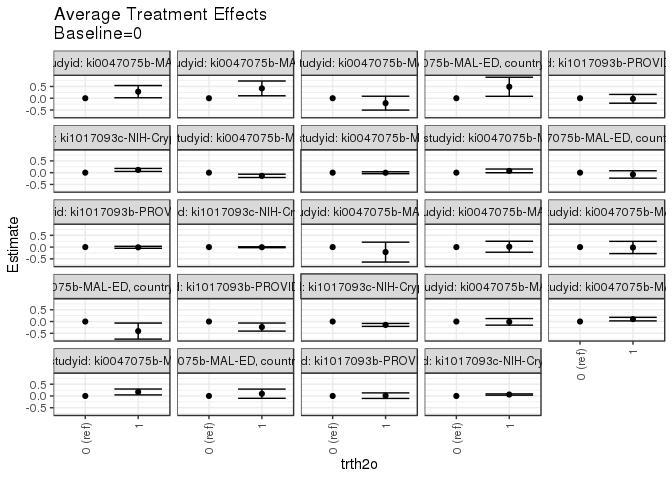

## Results Table

### Parameter: TSM

| agecat | studyid | country | intervention_level | baseline_level | estimate | ci_lower | ci_upper |
| --- | --- | --- | --- | --- | --- | --- | --- |
| 0-3 months | ki0047075b-MAL-ED | BRAZIL | 0 | NA | 4.0315373 | 3.8866194 | 4.1764552 |
| 0-3 months | ki0047075b-MAL-ED | BRAZIL | 1 | NA | 4.3116371 | 4.0953860 | 4.5278881 |
| 0-3 months | ki0047075b-MAL-ED | NEPAL | 0 | NA | 3.3146111 | 3.0218971 | 3.6073250 |
| 0-3 months | ki0047075b-MAL-ED | NEPAL | 1 | NA | 3.7330528 | 3.6163475 | 3.8497581 |
| 0-3 months | ki0047075b-MAL-ED | PERU | 0 | NA | 3.5110628 | 3.2812212 | 3.7409044 |
| 0-3 months | ki0047075b-MAL-ED | PERU | 1 | NA | 3.3018257 | 3.1177732 | 3.4858781 |
| 0-3 months | ki0047075b-MAL-ED | TANZANIA, UNITED REPUBLIC OF | 0 | NA | 3.1945125 | 2.9985906 | 3.3904344 |
| 0-3 months | ki0047075b-MAL-ED | TANZANIA, UNITED REPUBLIC OF | 1 | NA | 3.6820549 | 3.3277337 | 4.0363762 |
| 0-3 months | ki1017093b-PROVIDE | BANGLADESH | 0 | NA | 3.4827705 | 3.4430661 | 3.5224749 |
| 0-3 months | ki1017093b-PROVIDE | BANGLADESH | 1 | NA | 3.4584464 | 3.2755986 | 3.6412942 |
| 0-3 months | ki1017093c-NIH-Crypto | BANGLADESH | 0 | NA | 3.2991351 | 3.2568559 | 3.3414143 |
| 0-3 months | ki1017093c-NIH-Crypto | BANGLADESH | 1 | NA | 3.4159157 | 3.3682507 | 3.4635808 |
| 3-6 months | ki0047075b-MAL-ED | BRAZIL | 0 | NA | 2.2495836 | 2.1411219 | 2.3580453 |
| 3-6 months | ki0047075b-MAL-ED | BRAZIL | 1 | NA | 2.0370264 | 1.6269103 | 2.4471426 |
| 3-6 months | ki0047075b-MAL-ED | NEPAL | 0 | NA | 1.9220906 | 1.7157681 | 2.1284131 |
| 3-6 months | ki0047075b-MAL-ED | NEPAL | 1 | NA | 1.9373583 | 1.8289559 | 2.0457607 |
| 3-6 months | ki0047075b-MAL-ED | PERU | 0 | NA | 2.0034011 | 1.8105150 | 2.1962872 |
| 3-6 months | ki0047075b-MAL-ED | PERU | 1 | NA | 1.9870567 | 1.8134152 | 2.1606981 |
| 3-6 months | ki0047075b-MAL-ED | TANZANIA, UNITED REPUBLIC OF | 0 | NA | 1.8739708 | 1.7296439 | 2.0182977 |
| 3-6 months | ki0047075b-MAL-ED | TANZANIA, UNITED REPUBLIC OF | 1 | NA | 1.4680425 | 1.1592662 | 1.7768187 |
| 3-6 months | ki1017093b-PROVIDE | BANGLADESH | 0 | NA | 1.9706065 | 1.9352328 | 2.0059802 |
| 3-6 months | ki1017093b-PROVIDE | BANGLADESH | 1 | NA | 1.7355309 | 1.5685206 | 1.9025411 |
| 3-6 months | ki1017093c-NIH-Crypto | BANGLADESH | 0 | NA | 2.1815152 | 2.1362969 | 2.2267335 |
| 3-6 months | ki1017093c-NIH-Crypto | BANGLADESH | 1 | NA | 2.0377174 | 1.9955581 | 2.0798767 |
| 6-12 months | ki0047075b-MAL-ED | BRAZIL | 0 | NA | 1.4143807 | 1.3421119 | 1.4866494 |
| 6-12 months | ki0047075b-MAL-ED | BRAZIL | 1 | NA | 1.4007940 | 1.2799162 | 1.5216717 |
| 6-12 months | ki0047075b-MAL-ED | NEPAL | 0 | NA | 1.1038985 | 1.0394960 | 1.1683011 |
| 6-12 months | ki0047075b-MAL-ED | NEPAL | 1 | NA | 1.2062377 | 1.1592174 | 1.2532580 |
| 6-12 months | ki0047075b-MAL-ED | PERU | 0 | NA | 1.0357923 | 0.9453673 | 1.1262172 |
| 6-12 months | ki0047075b-MAL-ED | PERU | 1 | NA | 1.2056015 | 1.1198844 | 1.2913186 |
| 6-12 months | ki0047075b-MAL-ED | TANZANIA, UNITED REPUBLIC OF | 0 | NA | 1.0300848 | 0.9545728 | 1.1055968 |
| 6-12 months | ki0047075b-MAL-ED | TANZANIA, UNITED REPUBLIC OF | 1 | NA | 1.1257413 | 0.9455595 | 1.3059231 |
| 6-12 months | ki1017093b-PROVIDE | BANGLADESH | 0 | NA | 1.1728648 | 1.1553677 | 1.1903619 |
| 6-12 months | ki1017093b-PROVIDE | BANGLADESH | 1 | NA | 1.1859209 | 1.0698499 | 1.3019919 |
| 6-12 months | ki1017093c-NIH-Crypto | BANGLADESH | 0 | NA | 1.1684597 | 1.1494337 | 1.1874858 |
| 6-12 months | ki1017093c-NIH-Crypto | BANGLADESH | 1 | NA | 1.2290599 | 1.2084953 | 1.2496245 |
| 12-24 months | ki0047075b-MAL-ED | BRAZIL | 0 | NA | 0.9948817 | 0.9531846 | 1.0365789 |
| 12-24 months | ki0047075b-MAL-ED | BRAZIL | 1 | NA | 0.8593701 | 0.8028259 | 0.9159143 |
| 12-24 months | ki0047075b-MAL-ED | NEPAL | 0 | NA | 0.8801439 | 0.8503632 | 0.9099246 |
| 12-24 months | ki0047075b-MAL-ED | NEPAL | 1 | NA | 0.8770852 | 0.8498312 | 0.9043392 |
| 12-24 months | ki0047075b-MAL-ED | PERU | 0 | NA | 0.7852438 | 0.7236186 | 0.8468691 |
| 12-24 months | ki0047075b-MAL-ED | PERU | 1 | NA | 0.8610914 | 0.8128257 | 0.9093572 |
| 12-24 months | ki0047075b-MAL-ED | TANZANIA, UNITED REPUBLIC OF | 0 | NA | 0.7555402 | 0.7065698 | 0.8045106 |
| 12-24 months | ki0047075b-MAL-ED | TANZANIA, UNITED REPUBLIC OF | 1 | NA | 0.6796135 | 0.5299671 | 0.8292599 |
| 12-24 months | ki1017093b-PROVIDE | BANGLADESH | 0 | NA | 0.8577753 | 0.8455342 | 0.8700164 |
| 12-24 months | ki1017093b-PROVIDE | BANGLADESH | 1 | NA | 0.8484451 | 0.8080753 | 0.8888150 |
| 12-24 months | ki1017093c-NIH-Crypto | BANGLADESH | 0 | NA | 0.8660231 | 0.8522148 | 0.8798314 |
| 12-24 months | ki1017093c-NIH-Crypto | BANGLADESH | 1 | NA | 0.8604826 | 0.8461803 | 0.8747849 |

### Parameter: E(Y)

| agecat | studyid | country | intervention_level | baseline_level | estimate | ci_lower | ci_upper |
| --- | --- | --- | --- | --- | --- | --- | --- |
| 0-3 months | ki0047075b-MAL-ED | BRAZIL | NA | NA | 4.0715516 | 3.9418270 | 4.2012761 |
| 0-3 months | ki0047075b-MAL-ED | NEPAL | NA | NA | 3.6902242 | 3.5713067 | 3.8091418 |
| 0-3 months | ki0047075b-MAL-ED | PERU | NA | NA | 3.3427634 | 3.1861528 | 3.4993739 |
| 0-3 months | ki0047075b-MAL-ED | TANZANIA, UNITED REPUBLIC OF | NA | NA | 3.2714929 | 3.0881028 | 3.4548830 |
| 0-3 months | ki1017093b-PROVIDE | BANGLADESH | NA | NA | 3.4826706 | 3.4434873 | 3.5218539 |
| 0-3 months | ki1017093c-NIH-Crypto | BANGLADESH | NA | NA | 3.3028656 | 3.2646714 | 3.3410598 |
| 3-6 months | ki0047075b-MAL-ED | BRAZIL | NA | NA | 2.2227563 | 2.1133297 | 2.3321829 |
| 3-6 months | ki0047075b-MAL-ED | NEPAL | NA | NA | 1.9950101 | 1.8904604 | 2.0995599 |
| 3-6 months | ki0047075b-MAL-ED | PERU | NA | NA | 1.9903923 | 1.8466790 | 2.1341055 |
| 3-6 months | ki0047075b-MAL-ED | TANZANIA, UNITED REPUBLIC OF | NA | NA | 1.8159811 | 1.6776334 | 1.9543288 |
| 3-6 months | ki1017093b-PROVIDE | BANGLADESH | NA | NA | 1.9654454 | 1.9303798 | 2.0005110 |
| 3-6 months | ki1017093c-NIH-Crypto | BANGLADESH | NA | NA | 2.0057973 | 1.9693775 | 2.0422170 |
| 6-12 months | ki0047075b-MAL-ED | BRAZIL | NA | NA | 1.4128372 | 1.3473294 | 1.4783450 |
| 6-12 months | ki0047075b-MAL-ED | NEPAL | NA | NA | 1.1905799 | 1.1461403 | 1.2350196 |
| 6-12 months | ki0047075b-MAL-ED | PERU | NA | NA | 1.1709466 | 1.0976676 | 1.2442255 |
| 6-12 months | ki0047075b-MAL-ED | TANZANIA, UNITED REPUBLIC OF | NA | NA | 1.0440833 | 0.9736537 | 1.1145130 |
| 6-12 months | ki1017093b-PROVIDE | BANGLADESH | NA | NA | 1.1731762 | 1.1558671 | 1.1904853 |
| 6-12 months | ki1017093c-NIH-Crypto | BANGLADESH | NA | NA | 1.2281313 | 1.2106849 | 1.2455776 |
| 12-24 months | ki0047075b-MAL-ED | BRAZIL | NA | NA | 0.9771443 | 0.9389322 | 1.0153564 |
| 12-24 months | ki0047075b-MAL-ED | NEPAL | NA | NA | 0.8842512 | 0.8598045 | 0.9086979 |
| 12-24 months | ki0047075b-MAL-ED | PERU | NA | NA | 0.8452899 | 0.8040289 | 0.8865508 |
| 12-24 months | ki0047075b-MAL-ED | TANZANIA, UNITED REPUBLIC OF | NA | NA | 0.7446935 | 0.6968915 | 0.7924955 |
| 12-24 months | ki1017093b-PROVIDE | BANGLADESH | NA | NA | 0.8575519 | 0.8455586 | 0.8695452 |
| 12-24 months | ki1017093c-NIH-Crypto | BANGLADESH | NA | NA | 0.8755729 | 0.8637860 | 0.8873598 |

### Parameter: ATE

| agecat | studyid | country | intervention_level | baseline_level | estimate | ci_lower | ci_upper |
| --- | --- | --- | --- | --- | --- | --- | --- |
| 0-3 months | ki0047075b-MAL-ED | BRAZIL | 0 | 0 | 0.0000000 | 0.0000000 | 0.0000000 |
| 0-3 months | ki0047075b-MAL-ED | BRAZIL | 1 | 0 | 0.2800998 | 0.0197813 | 0.5404183 |
| 0-3 months | ki0047075b-MAL-ED | NEPAL | 0 | 0 | 0.0000000 | 0.0000000 | 0.0000000 |
| 0-3 months | ki0047075b-MAL-ED | NEPAL | 1 | 0 | 0.4184417 | 0.1040008 | 0.7328827 |
| 0-3 months | ki0047075b-MAL-ED | PERU | 0 | 0 | 0.0000000 | 0.0000000 | 0.0000000 |
| 0-3 months | ki0047075b-MAL-ED | PERU | 1 | 0 | -0.2092371 | -0.5036900 | 0.0852157 |
| 0-3 months | ki0047075b-MAL-ED | TANZANIA, UNITED REPUBLIC OF | 0 | 0 | 0.0000000 | 0.0000000 | 0.0000000 |
| 0-3 months | ki0047075b-MAL-ED | TANZANIA, UNITED REPUBLIC OF | 1 | 0 | 0.4875424 | 0.0826610 | 0.8924238 |
| 0-3 months | ki1017093b-PROVIDE | BANGLADESH | 0 | 0 | 0.0000000 | 0.0000000 | 0.0000000 |
| 0-3 months | ki1017093b-PROVIDE | BANGLADESH | 1 | 0 | -0.0243242 | -0.2109826 | 0.1623343 |
| 0-3 months | ki1017093c-NIH-Crypto | BANGLADESH | 0 | 0 | 0.0000000 | 0.0000000 | 0.0000000 |
| 0-3 months | ki1017093c-NIH-Crypto | BANGLADESH | 1 | 0 | 0.1167806 | 0.0526097 | 0.1809515 |
| 3-6 months | ki0047075b-MAL-ED | BRAZIL | 0 | 0 | 0.0000000 | 0.0000000 | 0.0000000 |
| 3-6 months | ki0047075b-MAL-ED | BRAZIL | 1 | 0 | -0.2125571 | -0.6355883 | 0.2104740 |
| 3-6 months | ki0047075b-MAL-ED | NEPAL | 0 | 0 | 0.0000000 | 0.0000000 | 0.0000000 |
| 3-6 months | ki0047075b-MAL-ED | NEPAL | 1 | 0 | 0.0152677 | -0.2177144 | 0.2482497 |
| 3-6 months | ki0047075b-MAL-ED | PERU | 0 | 0 | 0.0000000 | 0.0000000 | 0.0000000 |
| 3-6 months | ki0047075b-MAL-ED | PERU | 1 | 0 | -0.0163444 | -0.2758756 | 0.2431867 |
| 3-6 months | ki0047075b-MAL-ED | TANZANIA, UNITED REPUBLIC OF | 0 | 0 | 0.0000000 | 0.0000000 | 0.0000000 |
| 3-6 months | ki0047075b-MAL-ED | TANZANIA, UNITED REPUBLIC OF | 1 | 0 | -0.4059284 | -0.7467700 | -0.0650868 |
| 3-6 months | ki1017093b-PROVIDE | BANGLADESH | 0 | 0 | 0.0000000 | 0.0000000 | 0.0000000 |
| 3-6 months | ki1017093b-PROVIDE | BANGLADESH | 1 | 0 | -0.2350756 | -0.4055740 | -0.0645773 |
| 3-6 months | ki1017093c-NIH-Crypto | BANGLADESH | 0 | 0 | 0.0000000 | 0.0000000 | 0.0000000 |
| 3-6 months | ki1017093c-NIH-Crypto | BANGLADESH | 1 | 0 | -0.1437978 | -0.2059337 | -0.0816619 |
| 6-12 months | ki0047075b-MAL-ED | BRAZIL | 0 | 0 | 0.0000000 | 0.0000000 | 0.0000000 |
| 6-12 months | ki0047075b-MAL-ED | BRAZIL | 1 | 0 | -0.0135867 | -0.1535787 | 0.1264053 |
| 6-12 months | ki0047075b-MAL-ED | NEPAL | 0 | 0 | 0.0000000 | 0.0000000 | 0.0000000 |
| 6-12 months | ki0047075b-MAL-ED | NEPAL | 1 | 0 | 0.1023392 | 0.0264796 | 0.1781987 |
| 6-12 months | ki0047075b-MAL-ED | PERU | 0 | 0 | 0.0000000 | 0.0000000 | 0.0000000 |
| 6-12 months | ki0047075b-MAL-ED | PERU | 1 | 0 | 0.1698092 | 0.0452141 | 0.2944044 |
| 6-12 months | ki0047075b-MAL-ED | TANZANIA, UNITED REPUBLIC OF | 0 | 0 | 0.0000000 | 0.0000000 | 0.0000000 |
| 6-12 months | ki0047075b-MAL-ED | TANZANIA, UNITED REPUBLIC OF | 1 | 0 | 0.0956564 | -0.0997087 | 0.2910216 |
| 6-12 months | ki1017093b-PROVIDE | BANGLADESH | 0 | 0 | 0.0000000 | 0.0000000 | 0.0000000 |
| 6-12 months | ki1017093b-PROVIDE | BANGLADESH | 1 | 0 | 0.0130561 | -0.1042925 | 0.1304047 |
| 6-12 months | ki1017093c-NIH-Crypto | BANGLADESH | 0 | 0 | 0.0000000 | 0.0000000 | 0.0000000 |
| 6-12 months | ki1017093c-NIH-Crypto | BANGLADESH | 1 | 0 | 0.0606001 | 0.0345691 | 0.0866312 |
| 12-24 months | ki0047075b-MAL-ED | BRAZIL | 0 | 0 | 0.0000000 | 0.0000000 | 0.0000000 |
| 12-24 months | ki0047075b-MAL-ED | BRAZIL | 1 | 0 | -0.1355116 | -0.2056958 | -0.0653275 |
| 12-24 months | ki0047075b-MAL-ED | NEPAL | 0 | 0 | 0.0000000 | 0.0000000 | 0.0000000 |
| 12-24 months | ki0047075b-MAL-ED | NEPAL | 1 | 0 | -0.0030587 | -0.0435719 | 0.0374546 |
| 12-24 months | ki0047075b-MAL-ED | PERU | 0 | 0 | 0.0000000 | 0.0000000 | 0.0000000 |
| 12-24 months | ki0047075b-MAL-ED | PERU | 1 | 0 | 0.0758476 | -0.0024273 | 0.1541225 |
| 12-24 months | ki0047075b-MAL-ED | TANZANIA, UNITED REPUBLIC OF | 0 | 0 | 0.0000000 | 0.0000000 | 0.0000000 |
| 12-24 months | ki0047075b-MAL-ED | TANZANIA, UNITED REPUBLIC OF | 1 | 0 | -0.0759267 | -0.2333819 | 0.0815286 |
| 12-24 months | ki1017093b-PROVIDE | BANGLADESH | 0 | 0 | 0.0000000 | 0.0000000 | 0.0000000 |
| 12-24 months | ki1017093b-PROVIDE | BANGLADESH | 1 | 0 | -0.0093302 | -0.0514403 | 0.0327799 |
| 12-24 months | ki1017093c-NIH-Crypto | BANGLADESH | 0 | 0 | 0.0000000 | 0.0000000 | 0.0000000 |
| 12-24 months | ki1017093c-NIH-Crypto | BANGLADESH | 1 | 0 | -0.0055405 | -0.0255010 | 0.0144200 |